# NDVI_Analysis

```python
# import libraries

import logging
import os
import pathlib
import subprocess
import warnings
from glob import glob

import earthpy.appeears as etapp
import folium
import geopandas as gpd
import geoviews as gv
import geoviews.feature as gf
import holoviews as hv
import hvplot.pandas
import hvplot.xarray
import matplotlib.pyplot as plt
import pandas as pd
import rioxarray as rxr
import xarray as xr


# Set up logging so AppeearsDownloader will log in notebook
logging.basicConfig(level=logging.INFO)

# Ignore FutureWarning coming from hvplot
warnings.simplefilter(action="ignore", category=FutureWarning)
```

```python
# Create the path to the directory for a project related to the
# "Caldor Fire" data using the os and pathlib modules.
caldorfire_folder = os.path.join(
    pathlib.Path.home(), "earth-analytics", "data", "caldor_fire")

# Create the project directory
os.makedirs(caldorfire_folder, exist_ok=True)
```

```python
cf_bound_url = ("https://services3.arcgis.com/T4QMspbfLg3qTGWY/arcgis/rest/services/
                InterAgencyFirePerimeterHistory_All_Years_View/FeatureServer/0/
                query?where=FIRE_YEAR%20%3D%20'2021'%20AND%20
                INCIDENT%20%3D%20'CALDOR'&outFields=*&outSR=4326&f=json")

gpd.read_file(cf_bound_url)
```

|  | OBJECTID | MAP_METHOD | DATE_CUR | COMMENTS | GEO_ID | IRWINID | UNQE_FIRE_ID | FIRE_YEAR | LOCAL_NUM | INCIDENT | ... | POO_RESP_I | FEATURE_CA | GIS_ACRES | USER_NAME | SOURCE | AGENCY | FIRE_YEAR_INT | Shape__Area | Shape__Length | geometry |
| --- | --- | --- | --- | --- | --- | --- | --- | --- | --- | --- | --- | --- | --- | --- | --- | --- | --- | --- | --- | --- | --- |
| 0 | 87229 | Infrared Interpretation | 202202280000 | None | 54712675 | {E6C053C8-A346-43FB-9C29-632BC7536717} | 2021-CAENF-024030 | 2021 | 24030 | Caldor | ... | CAENF | Wildfire Final Perimeter | 221907.8 | None | USFS | USFS | 2021 | 1.476040e+09 | 472891.369665 | MULTIPOLYGON (((-120.63178 38.60512, -120.6317... |

1 rows × 21 columns

```python
# Create a interactive map using the Camp Fire boundary
# Read the shapefile using GeoPandas
cf_gdf = gpd.read_file(cf_bound_url)

# Create a Folium map
cf_map = folium.Map(location=[38.5, -120.8],
                    zoom_start=8,
                    scrollWheelZoom=False)

# Convert the GeoDataFrame to GeoJSON format
geojson_data = cf_gdf.to_json()

# Step 4: Add the GeoJSON data to the Folium map as a GeoJSON layer
folium.GeoJson(geojson_data).add_to(cf_map)

# Customize map settings
folium.TileLayer(
    tiles='http://server.arcgisonline.com/ArcGIS/rest/services/World_Imagery/MapServer/tile/{z}/{y}/{x}',
    attr='Esri World Imagery',
    name='Esri World Imagery',
    overlay=False,
).add_to(cf_map)
folium.Marker([38.67772446448718, -120.34211238355265], popup="Caldor Fire Perimeter").add_to(cf_map)

cf_map
```

Make this Notebook Trusted to load map: File -> Trust Notebook

[interactive chart not shown]

The Aqua satellite, a NASA mission, carries the MODIS sensor, which captures detailed Earth surface data. Among its applications, MODIS is crucial for vegetation monitoring. The NDVI (Normalized Difference Vegetation Index), derived from MODIS measurements, serves as an indicator of vegetation health. In the aftermath of a wildfire, assessing the impact on vegetation becomes essential. Here, NDVI plays a pivotal role in post-processing. By calculating the ratio of reflected near-infrared to red light, NDVI provides a quantitative measure of vegetation density and health. After a wildfire event, a decline in NDVI values typically indicates vegetation damage. As ecosystems strive to recover post-fire, monitoring changes in NDVI becomes a valuable tool. Increasing NDVI values over time signal vegetation regrowth and recovery. This information is crucial for environmental scientists, land managers, and policymakers, as it allows them to evaluate the success of restoration efforts, identify areas requiring intervention, and make informed decisions regarding land use and conservation strategies.

In summary, the Aqua satellite and its MODIS sensor, coupled with the NDVI post-processing technique, enable a comprehensive and quantitative assessment of vegetation recovery after a wildfire. This information is instrumental in understanding the ecological impact of wildfires and in formulating effective strategies for land management and ecosystem restoration.

http://doi.org/10.5067/MODIS/MOD09A1.006 (Terra)

http://doi.org/10.5067/MODIS/MYD09A1.006 (Aqua)

```python
# Initialize AppeearsDownloader for MODIS NDVI data
ndvi_downloader = etapp.AppeearsDownloader(
    download_key="modis-ndvi",
    ea_dir="/c/Users/skcor/earth-analytics/data/caldor_fire",
    product="MYD13Q1.061",
    layer="_250m_16_days_NDVI",
    start_date="06-01",
    end_date="08-31",
    recurring=True,
    year_range=[2017, 2023],
    polygon=cf_gdf,
)

# Download files if the download directory does not exist
if not os.path.exists(ndvi_downloader.data_dir):
    ndvi_downloader.download_files()

ndvi_downloader
```

[output not shown]

[output cut: 289 more lines]

[output not shown]

```
<earthpy.appeears.AppeearsDownloader at 0x151d5a5ea70>
```

```python
# Load NDVI tif files into Python
ndvi_path_list = glob(os.path.join(ndvi_downloader.data_dir, '*',
                                   '*NDVI*.tif'))
```

```python
# Import and organize files
doy_start = -19
doy_end = -12
scale_factor = 10000

ndvi_da_list = []
for ndvi_path in ndvi_path_list:
    # Get date from file name
    doy = ndvi_path[doy_start:doy_end]
    date = pd.to_datetime(doy, format="%Y%j")

    # Open dataset
    da = rxr.open_rasterio(ndvi_path, masked=True).squeeze()

    # Prepare to concatenate: Add date dimension and clean up metadata
    da = da.assign_coords({"date": date})
    da = da.expand_dims({"date": 1})
    da.name = "NDVI"

# Divide by scale factor
    da = da / scale_factor
# Add the DataArray to the end of the accumulator list
    ndvi_da_list.append(da)
```

```python
# Stack the NDVI arrays by date
ndvi_ds = xr.combine_by_coords(ndvi_da_list, coords=['date'])
ndvi_ds
```

```
<xarray.Dataset>
Dimensions:      (x: 360, y: 161, date: 48)
Coordinates:
    band         int32 1
  * x            (x) float64 -120.7 -120.7 -120.7 ... -119.9 -119.9 -119.9
  * y            (y) float64 38.89 38.89 38.89 38.88 ... 38.56 38.56 38.56 38.56
    spatial_ref  int32 0
  * date         (date) datetime64[ns] 2017-05-17 2017-06-02 ... 2023-08-21
Data variables:
    NDVI         (date, y, x) float32 0.7979 0.7937 0.789 ... 0.6106 0.6094
```

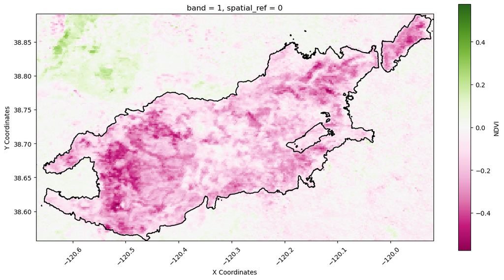

```python
# Calculate the change in NDVI pre and post Camp Fire

# Select data from 2019 and 2017 fire years
data_2023 = ndvi_ds.sel(date="2023")
data_2017 = ndvi_ds.sel(date="2017")


# Calculate the temporal mean for 2017 and 2019
temporal_mean_2017 = data_2017.mean(dim="date")
temporal_mean_2023 = data_2023.mean(dim="date")

# Calculate the difference between the temporal means
dif_ndvi_da = temporal_mean_2023 - temporal_mean_2017



# Assuming your 'difference' xarray has 'x' and 'y' coordinates
plt.figure(figsize=(14,7))
plot_ndvi = dif_ndvi_da.NDVI.plot(cmap=plt.colormaps['PiYG'])
plt.xlabel('X Coordinates')
plt.ylabel('Y Coordinates')
plt.xticks(rotation=45)

# Plot the boundary from the GeoDataFrame
cf_gdf.plot(ax=plt.gca(), facecolor='none', edgecolor='black',
            linewidth=1.5)



# Display the plot
plt.show(plot_ndvi)
```

```python
# Create working envelope (outside fire boundary) of the Camp Fire boundary
envelope_gdf = gpd.GeoDataFrame(geometry=cf_gdf.envelope)

# Calculate the area difference between inside and outside polygons
out_gdf = gpd.overlay(envelope_gdf, cf_gdf, how='difference')



# Clip both the Camp Fire and the outside of the Camp Fire polygon
ndvi_fire_ds = ndvi_ds.rio.clip(cf_gdf.geometry)
ndvi_out_ds = ndvi_ds.rio.clip(out_gdf.geometry)
```

```python
# Group the data by year, take the mean, and convert the dataset to a
# dataframe
ndvi_fire_df = (
    ndvi_fire_ds.groupby(ndvi_ds.date.dt.year)
    .mean(...)
    .NDVI.to_dataframe()[["NDVI"]]
)
ndvi_out_df = (
    ndvi_out_ds.groupby(ndvi_ds.date.dt.year)
    .mean(...)
    .NDVI.to_dataframe()[["NDVI"]]
)

ndvi_fire_df, ndvi_out_df
```

```
(          NDVI
 year
 2017  0.666571
 2018  0.675332
 2019  0.627909
 2020  0.675637
 2021  0.620697
 2022  0.414593
 2023  0.467667,
           NDVI
 year
 2017  0.521477
 2018  0.551232
 2019  0.504716
 2020  0.556747
 2021  0.540434
 2022  0.552275
 2023  0.515255)
```

```python
# Plot the NDVI difference value for each year
(ndvi_fire_df - ndvi_out_df).hvplot(
    xlabel="Year",
    ylabel="dNDVI",
    title=(
        "Plot exhibits the difference between the mean NDVI values"
        "\ninside and outside the Caldor fire boundary"))
```

[output not shown]

Within the Caldor Fire boundary, NDVI values remain persistently low, signaling ongoing challenges in vegetation recovery. The aftermath of the wildfire has left a profound impact on the landscape, with severely damaged or completely burned vegetation contributing to depressed NDVI readings. The persistent low values suggest a slow regrowth and rehabilitation process, highlighting the prolonged impact of the fire on the ecosystem. Monitoring and analyzing these NDVI trends within the fire-affected area are crucial for assessing the extent of ecological damage and informing targeted interventions and land management strategies to support the recovery of the affected vegetation.

```python
%%bash
jupyter nbconvert NDVI_Analysis.ipynb --to html
```

```
[NbConvertApp] Converting notebook NDVI_Analysis.ipynb to html
[NbConvertApp] WARNING | Alternative text is missing on 1 image(s).
[NbConvertApp] Writing 1618869 bytes to NDVI_Analysis.html
```